# Reproducible Research Project 1

Lucas

June 28, 2016

*criterion 1*  
Required packages are loaded, working directories are selected and files downloaded, unzipped and read into R.

```r
library(ggplot2)
library(dplyr)

workdir <- "~/Documents/Courses/Data specialization Johns Hopkins/05_Reproducible Research/week 2/project_1/"
setwd(workdir)

download.file("https://d396qusza40orc.cloudfront.net/repdata%2Fdata%2Factivity.zip", "data.zip")
unzip("data.zip")
activity <- read.csv("activity.csv")
```

*criterion 1*  
**Variable recoding** is performed to create a separate dataset (called “perday”) that holds the numbers of steps per day.

```r
#recode into steps / day
days <- as.character(unique(activity$date))
stepsperday <- c()
for(i in seq_along(days)) {
  stepsperday <- c(stepsperday, sum(activity[which(activity$date ==days[i]), 1], na.rm = TRUE))
}
perday <- data.frame(cbind(days, stepsperday))
perday$days <- as.POSIXct(perday$days)
perday$stepsperday <- as.numeric(as.character(perday$stepsperday))
```

*criterion 2*  
A **histogram with counts of steps per day** (with bins of 1000 steps) is created.

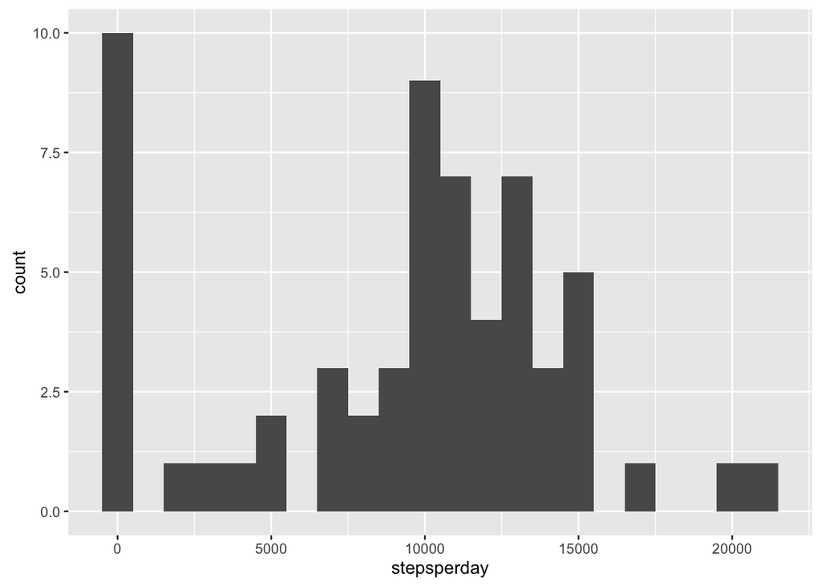

```r
#histogram
hist <- ggplot(data = perday, aes(stepsperday))
hist + geom_histogram(binwidth = 1000)
```

*criterion 3*  
The **mean and median** of steps per day are calculated

```r
#mean and median
meansteps <- mean(perday$stepsperday, na.rm = TRUE)
mediansteps <- median(perday$stepsperday, na.rm = TRUE)
meansteps
```

```
## [1] 9354.23
```

```r
mediansteps
```

```
## [1] 10395
```

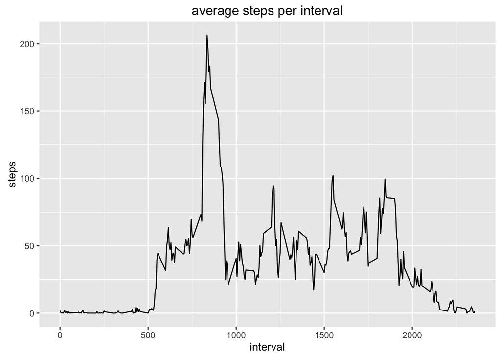

```r
#timeseries
time <- ggplot(data = activity, aes(x = interval, y = steps))
time + stat_summary(fun.y="mean", geom="line") + ggtitle("average steps per interval")
```

*criterion 5*  
The **interval that contains the maximum number of steps* is identified

```r
#interval with max steps
activity[which(activity$steps == max(activity$steps, na.rm = TRUE)), 2:3]
```

```
##             date interval
## 16492 2012-11-27      615
```

*criterion 6*  
The number of NA values for number of steps per interval in the dataset is shown. strategy for **imputing missing data** (steps per interval) with the mean of steps per interval is shown below and implemented. This strategy is implemented on the raw dataset which is then used to recreated the steps per day dataset with missing datafields replaced (stepsperday_new)

```r
#count NAs
length(activity[which(is.na(activity$steps)), 1])
```

```
## [1] 2304
```

```r
#imputation of the sample mean at missing data points on the raw (=steps per interval) data
meansteps_interval <- mean(activity$steps, na.rm = TRUE)
activity[is.na(activity$steps), 1] <- meansteps_interval

#creating new dataset of steps per day with imputed datapoints
stepsperday_new <- c()
for(i in seq_along(days)) {
  stepsperday_new <- c(stepsperday_new, sum(activity[which(activity$date == days[i]), 1], na.rm = TRUE))
}
perday_new <- data.frame(cbind(days, stepsperday_new))
perday_new$days <- as.POSIXct(perday_new$days)
perday_new$stepsperday_new <- as.numeric(as.character(perday_new$stepsperday_new))
```

*criterion 7*  
A **histogram** of the steps per day data after the imputation is made.

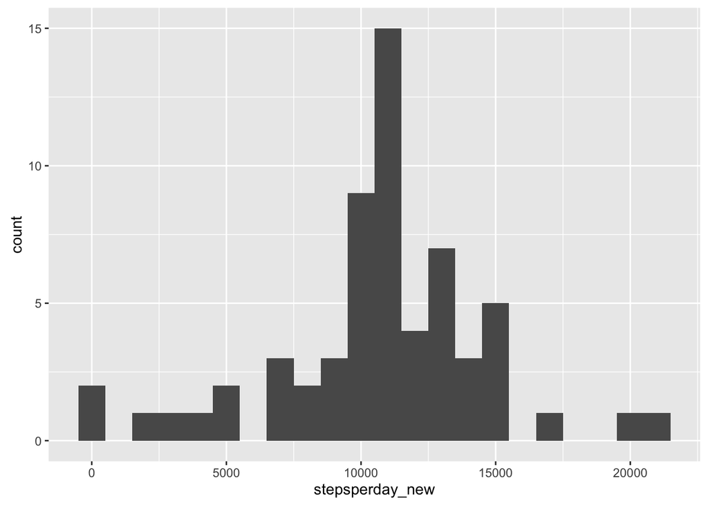

```r
#histogram
hist_new <- ggplot(data = perday_new, aes(stepsperday_new))
hist_new + geom_histogram(binwidth = 1000)
```

*criterion 8*  
A **timeseries panel plot** is created to show the difference in average of mean steps per 5 minute interval between weekdays and weekend days.

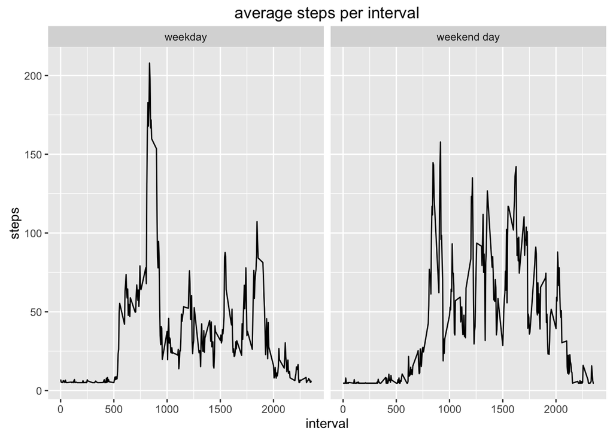

```r
#create panel plot for weekdays vs weekends
activity$date <- as.POSIXct(activity$date)
activity <- mutate(activity, weekday = weekdays(date))
activity <- mutate(activity, workday = "weekday")
activity[which(activity$weekday == "Saturday" | activity$weekday == "Sunday"), 5] <- "weekend day"
activity$workday <- as.factor(activity$workday)

time2 <- ggplot(data = activity, aes(x = interval, y = steps))
time2 + stat_summary(fun.y="mean", geom="line") + facet_grid(. ~ workday)  + ggtitle("average steps per interval")
```